# Proyecto 3 — DBSCAN, t-SNE y Comparación de Modelos de Clustering

## Integrantes

- Daniel Fernando Salgado Santamaría
- Jairo Wladimir Jhayya Perlaza
- Luis Gabriel Salgado Santamaría
- Oscar Paul Naranjo Castro

**Fecha:** 2026-05-14  
**Notebook:** 04-jj-dbscan-tsne-clientes.ipynb

## Configuración del entorno

Se importan todas las librerías necesarias para clustering (DBSCAN), reducción de dimensionalidad (PCA, t-SNE), visualización y análisis estadístico.

```python
# Importa librerías estándar de manejo de rutas y sistema.
import sys
from pathlib import Path

# Importa librerías numéricas y de análisis de datos.
import numpy as np
import pandas as pd

# Importa herramientas de visualización de alta calidad.
import matplotlib.pyplot as plt
import matplotlib.patches as mpatches
import seaborn as sns

# Importa modelos y métricas de scikit-learn para clustering y reducción.
from sklearn.preprocessing import StandardScaler
from sklearn.cluster import DBSCAN, KMeans
from sklearn.decomposition import PCA
from sklearn.manifold import TSNE
from sklearn.metrics import silhouette_score
from sklearn.neighbors import NearestNeighbors

# Verifica que el notebook esté usando el entorno virtual correcto.
print("Python ejecutándose desde:")
print(sys.executable)
```

```
Python ejecutándose desde:
g:\ProyectosPython\proyecto3\.venv\Scripts\python.exe
```

## Configuración visual global

Se establece el estilo, resolución y tamaño de fuente para todos los gráficos del notebook, asegurando uniformidad visual y calidad de exportación a 400 DPI.

```python
# Configura el estilo visual global: grilla limpia, contexto 'talk' para fuentes legibles.
sns.set_theme(style="whitegrid", context="talk")

# Establece resolución de pantalla y de guardado para gráficos de alta calidad.
plt.rcParams["figure.dpi"]        = 140
plt.rcParams["savefig.dpi"]       = 400
plt.rcParams["axes.titlesize"]    = 16
plt.rcParams["axes.labelsize"]    = 13
plt.rcParams["xtick.labelsize"]   = 11
plt.rcParams["ytick.labelsize"]   = 11
plt.rcParams["legend.fontsize"]   = 11
plt.rcParams["font.weight"]       = "regular"
plt.rcParams["axes.titleweight"]  = "bold"
plt.rcParams["axes.labelweight"]  = "bold"

# Define la paleta de colores vivos y profesionales usada en todo el proyecto.
PALETTE_VIVID = [
    "#0F766E",  # teal intenso
    "#2563EB",  # azul vivo
    "#DC2626",  # rojo elegante
    "#F59E0B",  # ámbar
    "#7C3AED",  # violeta controlado
    "#059669",  # verde fuerte
    "#EA580C",  # naranja profundo
    "#DB2777",  # magenta elegante
    "#0891B2",  # cyan fuerte
    "#65A30D",  # lima oscura
]

print("Configuración visual aplicada correctamente.")
```

```
Configuración visual aplicada correctamente.
```

## Definición de rutas del proyecto

Se definen rutas absolutas de forma reproducible para que el notebook funcione correctamente desde cualquier máquina del equipo sin necesidad de modificar paths manualmente.

```python
# Define la raíz del proyecto de forma dinámica según desde dónde se ejecute el notebook.
PROJECT_ROOT = (
    Path.cwd().resolve().parent
    if Path.cwd().name == "notebooks"
    else Path.cwd().resolve()
)

# Define rutas de datos procesados y carpetas de figuras y tablas.
PROCESSED_DIR  = PROJECT_ROOT / "data"    / "processed"
FIGURES_DBSCAN = PROJECT_ROOT / "reports" / "figures" / "dbscan"
FIGURES_TSNE   = PROJECT_ROOT / "reports" / "figures" / "tsne"
FIGURES_CMP    = PROJECT_ROOT / "reports" / "figures" / "clustering_clientes"
TABLES_DIR     = PROJECT_ROOT / "reports" / "tables"

# Crea las carpetas de destino si no existen.
for path in [FIGURES_DBSCAN, FIGURES_TSNE, FIGURES_CMP, TABLES_DIR]:
    path.mkdir(parents=True, exist_ok=True)

print("PROJECT_ROOT  :", PROJECT_ROOT)
print("PROCESSED_DIR :", PROCESSED_DIR)
print("FIGURES_DBSCAN:", FIGURES_DBSCAN)
print("FIGURES_TSNE  :", FIGURES_TSNE)
```

```
PROJECT_ROOT  : G:\ProyectosPython\proyecto3\desarrollo3
PROCESSED_DIR : G:\ProyectosPython\proyecto3\desarrollo3\data\processed
FIGURES_DBSCAN: G:\ProyectosPython\proyecto3\desarrollo3\reports\figures\dbscan
FIGURES_TSNE  : G:\ProyectosPython\proyecto3\desarrollo3\reports\figures\tsne
```

## Funciones auxiliares

Se definen funciones reutilizables para guardar figuras y anotar barras con valores, garantizando uniformidad visual en todos los gráficos del notebook.

```python
# Define función para guardar la figura actual en alta resolución en la carpeta indicada.
def f_save_plot(filename, folder):
    """Guarda la figura activa en la carpeta especificada a 400 DPI."""
    plt.savefig(folder / filename, dpi=400, bbox_inches="tight", facecolor="white")

# Define función para anotar barras verticales con su valor encima de cada barra.
def f_annotate_bars(ax, fmt="{:.0f}", suffix="", fontsize=10, weight="bold"):
    """Añade etiquetas sobre cada barra vertical del gráfico."""
    for patch in ax.patches:
        height = patch.get_height()
        if pd.notnull(height):
            x = patch.get_x() + patch.get_width() / 2
            ax.annotate(
                fmt.format(height) + suffix,
                (x, height),
                ha="center", va="bottom",
                fontsize=fontsize, fontweight=weight,
                xytext=(0, 6), textcoords="offset points"
            )

# Define función para anotar barras horizontales con su valor al final de cada barra.
def f_annotate_bars_horizontal(ax, fmt="{:.2f}", suffix="", fontsize=10, weight="bold"):
    """Añade etiquetas al final de cada barra horizontal del gráfico."""
    for patch in ax.patches:
        width = patch.get_width()
        y = patch.get_y() + patch.get_height() / 2
        if pd.notnull(width):
            ax.annotate(
                fmt.format(width) + suffix,
                (width, y),
                ha="left", va="center",
                fontsize=fontsize, fontweight=weight,
                xytext=(6, 0), textcoords="offset points"
            )

print("Funciones auxiliares definidas correctamente.")
```

```
Funciones auxiliares definidas correctamente.
```

## 1. Carga y verificación de datos

Se carga el archivo `customer_features.csv` generado en el notebook 02 (EDA), que contiene las métricas consolidadas por cliente: edad, número de sesiones, órdenes, ingresos, ticket promedio y reseñas. Este archivo es la base para todos los modelos de este notebook.

```python
# Carga el archivo de características de clientes generado en el notebook de EDA.
customer_features = pd.read_csv(PROCESSED_DIR / "customer_features.csv")

# Muestra las dimensiones y primeras filas para verificar integridad del archivo.
print("Dimensiones:", customer_features.shape)
customer_features.head()
```

```
Dimensiones: (20000, 10)
```

|  | customer_id | country | age | signup_date | marketing_opt_in | n_sessions | n_orders | gross_revenue_usd | avg_order_value_usd | n_reviews |
| --- | --- | --- | --- | --- | --- | --- | --- | --- | --- | --- |
| 0 | 1 | JP | 71 | 2020-09-04 | True | 5.0 | 2.0 | 115.39 | 57.695 | 1.0 |
| 1 | 2 | IN | 26 | 2020-04-05 | False | 3.0 | 2.0 | 68.52 | 34.260 | 0.0 |
| 2 | 3 | BR | 21 | 2023-08-31 | True | 5.0 | 1.0 | 66.72 | 66.720 | 0.0 |
| 3 | 4 | FR | 63 | 2022-06-30 | True | 9.0 | 2.0 | 279.86 | 139.930 | 0.0 |
| 4 | 5 | BR | 19 | 2022-07-22 | True | 9.0 | 3.0 | 271.29 | 90.430 | 4.0 |

```python
# Verifica que no haya valores nulos en ninguna de las columnas del dataset.
print("Valores nulos por columna:")
print(customer_features.isnull().sum())
```

```
Valores nulos por columna:
customer_id            0
country                0
age                    0
signup_date            0
marketing_opt_in       0
n_sessions             0
n_orders               0
gross_revenue_usd      0
avg_order_value_usd    0
n_reviews              0
dtype: int64
```

## 2. Preprocesamiento para clustering

DBSCAN y t-SNE son sensibles a la escala de las variables. Se seleccionan únicamente las variables numéricas de comportamiento y se aplica `StandardScaler` para normalizar cada variable a media 0 y desviación estándar 1, eliminando el efecto de magnitud.

```python
# Define las variables numéricas de comportamiento para el análisis de clustering.
# Se excluyen identificadores (customer_id) y fechas (signup_date).
FEATURE_COLS = [
    "age",
    "n_sessions",
    "n_orders",
    "gross_revenue_usd",
    "avg_order_value_usd",
    "n_reviews",
]

# Filtra solo las columnas disponibles en el dataset para evitar errores.
FEATURE_COLS = [c for c in FEATURE_COLS if c in customer_features.columns]
print("Variables utilizadas para clustering:")
print(FEATURE_COLS)

# Extrae la matriz de características y escala a media=0, std=1.
X = customer_features[FEATURE_COLS].copy()
scaler = StandardScaler()
X_scaled = scaler.fit_transform(X)

print(f"\nMatriz escalada: {X_scaled.shape[0]} clientes × {X_scaled.shape[1]} variables")
```

```
Variables utilizadas para clustering:
['age', 'n_sessions', 'n_orders', 'gross_revenue_usd', 'avg_order_value_usd', 'n_reviews']

Matriz escalada: 20000 clientes × 6 variables
```

## 3. Búsqueda del parámetro ε óptimo para DBSCAN

Para determinar el valor óptimo de `eps` (radio de vecindad en DBSCAN) se usa el **K-Distance Graph**: se calcula la distancia al k-ésimo vecino más cercano de cada punto (donde k = `min_samples - 1`) y se grafica en orden descendente. El punto de mayor curvatura (*codo*) indica el valor de `eps` donde la densidad cambia abruptamente, separando clusters de ruido.

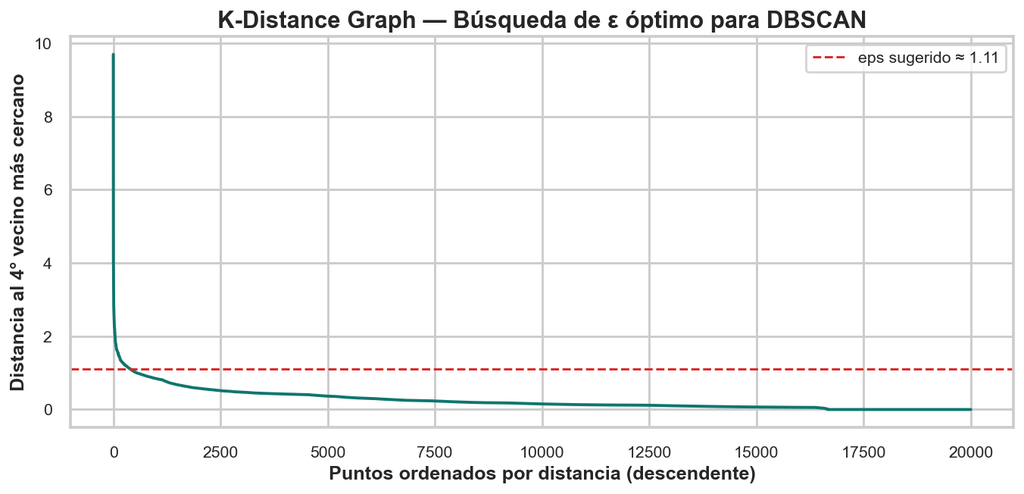

```
Valor de eps sugerido por K-Distance Graph: 1.11
```

```python
# Calcula las distancias al 4° vecino más cercano de cada punto (k=4 → min_samples=5).
k = 4
nbrs = NearestNeighbors(n_neighbors=k).fit(X_scaled)
distances, _ = nbrs.kneighbors(X_scaled)

# Extrae la distancia al vecino más lejano (k-ésimo) y ordena de mayor a menor.
k_distances = np.sort(distances[:, -1])[::-1]

# Grafica el K-Distance Graph para identificar visualmente el codo (eps óptimo).
plt.figure(figsize=(10, 5))
plt.plot(k_distances, color=PALETTE_VIVID[0], linewidth=2)
plt.axhline(
    y=k_distances[int(len(k_distances) * 0.02)],
    color=PALETTE_VIVID[2], linestyle="--", linewidth=1.5,
    label=f"eps sugerido ≈ {k_distances[int(len(k_distances)*0.02)]:.2f}"
)
plt.title("K-Distance Graph — Búsqueda de ε óptimo para DBSCAN")
plt.xlabel("Puntos ordenados por distancia (descendente)")
plt.ylabel(f"Distancia al {k}° vecino más cercano")
plt.legend(fontsize=11)
plt.tight_layout()
f_save_plot("kdistance_graph_dbscan.png", FIGURES_DBSCAN)
plt.show()

# Imprime el valor sugerido de eps para guiar la selección del parámetro.
eps_sugerido = round(k_distances[int(len(k_distances) * 0.02)], 2)
print(f"Valor de eps sugerido por K-Distance Graph: {eps_sugerido}")
```

## 4. Modelo DBSCAN — Ajuste de parámetros

Con el valor de `eps` identificado en el K-Distance Graph, se entrena el modelo DBSCAN. El parámetro `min_samples` controla la densidad mínima para que un punto sea considerado núcleo; un valor de 5 es adecuado para datasets con más de 1000 observaciones.

Los puntos etiquetados como **-1** son considerados **ruido** (outliers que no pertenecen a ningún cluster), lo cual es una característica diferenciadora respecto a K-Means.

```python
# Entrena el modelo DBSCAN con el eps identificado y min_samples=5.
EPS         = eps_sugerido
MIN_SAMPLES = 5

dbscan = DBSCAN(eps=EPS, min_samples=MIN_SAMPLES)
labels_dbscan = dbscan.fit_predict(X_scaled)

# Agrega las etiquetas DBSCAN al DataFrame original para análisis posterior.
customer_features["cluster_dbscan"] = labels_dbscan

# Calcula métricas clave del resultado del modelo.
n_clusters_dbscan = len(set(labels_dbscan)) - (1 if -1 in labels_dbscan else 0)
n_noise           = (labels_dbscan == -1).sum()
pct_noise         = n_noise / len(labels_dbscan) * 100

print(f"Parámetros usados   → eps={EPS}, min_samples={MIN_SAMPLES}")
print(f"Clusters encontrados: {n_clusters_dbscan}")
print(f"Puntos de ruido     : {n_noise} ({pct_noise:.1f}% del total)")
print("\nDistribución de clusters (incluyendo ruido=-1):")
print(customer_features["cluster_dbscan"].value_counts().sort_index())
```

```
Parámetros usados   → eps=1.11, min_samples=5
Clusters encontrados: 5
Puntos de ruido     : 266 (1.3% del total)

Distribución de clusters (incluyendo ruido=-1):
cluster_dbscan
-1      266
 0    19710
 1        9
 2        5
 3        5
 4        5
Name: count, dtype: int64
```

```python
# Calcula el Silhouette Score de DBSCAN excluyendo los puntos de ruido (-1).
# El silhouette solo es válido cuando hay al menos 2 clusters con puntos no-ruido.
mask_no_noise = labels_dbscan != -1

if n_clusters_dbscan >= 2 and mask_no_noise.sum() > 1:
    sil_dbscan = silhouette_score(
        X_scaled[mask_no_noise], labels_dbscan[mask_no_noise]
    )
    print(f"Silhouette Score DBSCAN (sin ruido): {sil_dbscan:.4f}")
else:
    sil_dbscan = None
    print("No se puede calcular Silhouette Score: clusters insuficientes.")
```

```
Silhouette Score DBSCAN (sin ruido): 0.4491
```

## 5. Visualización de resultados DBSCAN

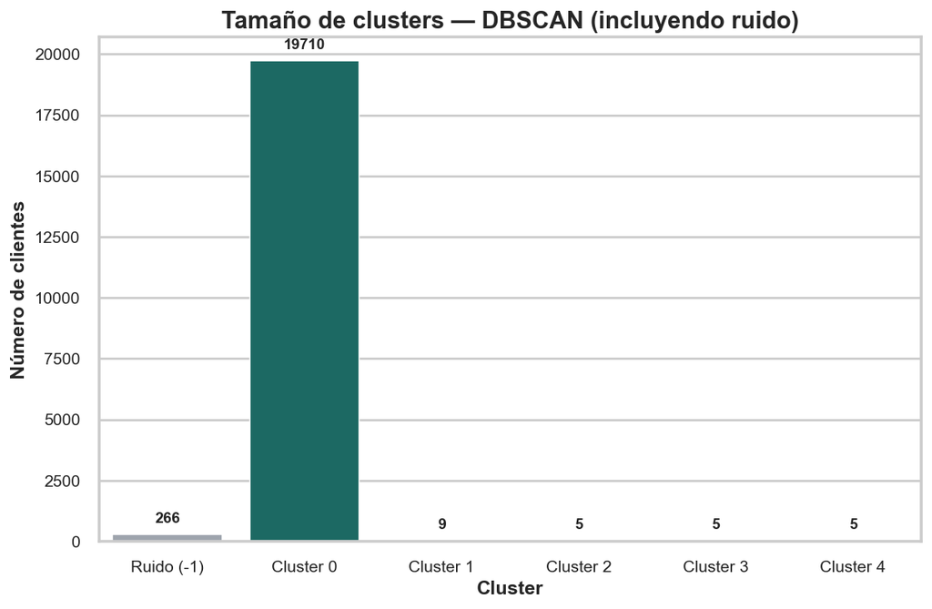

```
Gráfico guardado: tamano_clusters_dbscan.png
```

```python
# ── Gráfico 1: Tamaño de clusters DBSCAN incluyendo puntos de ruido ──────────
cluster_counts_dbscan = (
    customer_features["cluster_dbscan"]
    .value_counts()
    .sort_index()
    .reset_index()
)
cluster_counts_dbscan.columns = ["cluster", "count"]

# Asigna etiquetas descriptivas: ruido aparece como 'Ruido (-1)'.
cluster_counts_dbscan["label"] = cluster_counts_dbscan["cluster"].apply(
    lambda x: "Ruido (-1)" if x == -1 else f"Cluster {x}"
)

# Define colores: ruido en gris, clusters en paleta vívida.
colors_dbscan = []
vivid_idx = 0
for c in cluster_counts_dbscan["cluster"]:
    if c == -1:
        colors_dbscan.append("#9CA3AF")
    else:
        colors_dbscan.append(PALETTE_VIVID[vivid_idx % len(PALETTE_VIVID)])
        vivid_idx += 1

plt.figure(figsize=(max(8, len(cluster_counts_dbscan) * 1.5), 6))
ax = sns.barplot(
    data=cluster_counts_dbscan,
    x="label", y="count",
    palette=colors_dbscan,
    edgecolor="white", linewidth=0.8
)
f_annotate_bars(ax, fmt="{:.0f}")
plt.title("Tamaño de clusters — DBSCAN (incluyendo ruido)")
plt.xlabel("Cluster")
plt.ylabel("Número de clientes")
plt.tight_layout()
f_save_plot("tamano_clusters_dbscan.png", FIGURES_DBSCAN)
plt.show()
print("Gráfico guardado: tamano_clusters_dbscan.png")
```

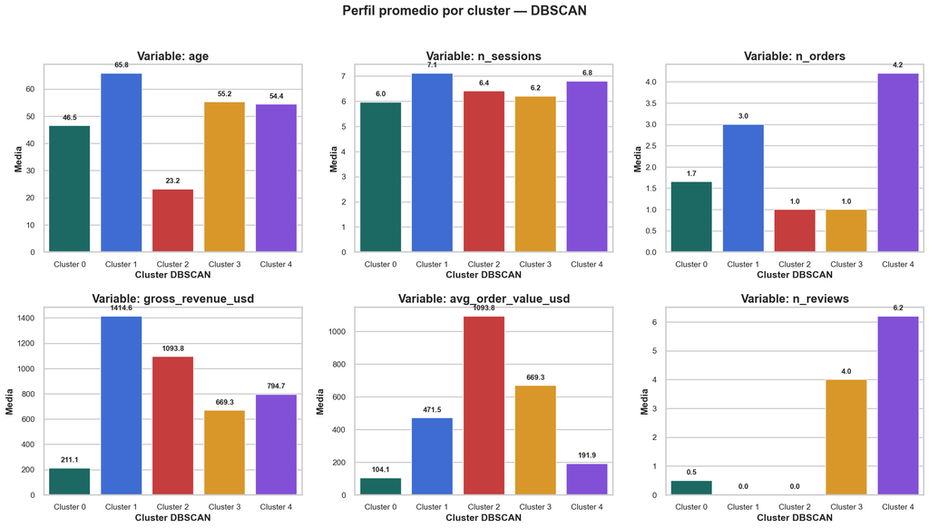

```
Gráfico guardado: perfil_promedio_clusters_dbscan.png
```

```python
# ── Gráfico 2: Perfil promedio por cluster DBSCAN (excluye ruido) ─────────────
# Calcula la media de cada variable de comportamiento agrupando por cluster DBSCAN.
profile_dbscan = (
    customer_features[customer_features["cluster_dbscan"] != -1]
    .groupby("cluster_dbscan")[FEATURE_COLS]
    .mean()
    .reset_index()
)

# Convierte cluster_dbscan a string para usarlo como hue categórico en seaborn.
profile_dbscan["cluster_label"] = profile_dbscan["cluster_dbscan"].apply(
    lambda x: f"Cluster {int(x)}"
)

# Construye paleta como lista ordenada por aparición de clusters.
n_clusters_plot = profile_dbscan["cluster_label"].nunique()
palette_list = PALETTE_VIVID[:n_clusters_plot]

# Genera un subgráfico por variable para comparar el perfil de cada cluster.
n_vars = len(FEATURE_COLS)
fig, axes = plt.subplots(2, 3, figsize=(18, 10))
axes = axes.flatten()

for i, var in enumerate(FEATURE_COLS):
    ax = axes[i]
    sns.barplot(
        data=profile_dbscan,
        x="cluster_label", y=var,
        hue="cluster_label",
        palette=palette_list,
        edgecolor="white", linewidth=0.8,
        legend=False,
        ax=ax
    )
    f_annotate_bars(ax, fmt="{:.1f}")
    ax.set_title(f"Variable: {var}", fontweight="bold")
    ax.set_xlabel("Cluster DBSCAN")
    ax.set_ylabel("Media")

# Oculta el último subgráfico si hay espacio sobrante.
for j in range(n_vars, len(axes)):
    axes[j].set_visible(False)

plt.suptitle("Perfil promedio por cluster — DBSCAN",
             fontsize=18, fontweight="bold", y=1.01)
plt.tight_layout()
f_save_plot("perfil_promedio_clusters_dbscan.png", FIGURES_DBSCAN)
plt.show()
print("Gráfico guardado: perfil_promedio_clusters_dbscan.png")
```

## 6. t-SNE — Reducción bidimensional

**t-SNE** (t-Distributed Stochastic Neighbor Embedding) es una técnica no lineal de reducción de dimensionalidad especialmente efectiva para visualizar estructuras de agrupamiento complejas en 2D. A diferencia de PCA (que preserva varianza global), t-SNE preserva relaciones de **vecindad local**, revelando agrupaciones que no son visibles en proyecciones lineales.

Parámetros clave:

- `perplexity`: controla el balance entre estructura local y global (valor típico: 30–50).
- `n_iter`: número de iteraciones para convergencia (mínimo recomendado: 1000).
- `random_state`: fija la semilla para reproducibilidad.

```python
# Aplica t-SNE sobre la matriz escalada para obtener representación 2D de los clientes.
# NOTA: En scikit-learn >= 1.5 el parámetro n_iter se renombró a max_iter.
tsne = TSNE(
    n_components=2,
    perplexity=40,
    max_iter=1000,
    random_state=42,
    learning_rate="auto",
    init="pca"        # inicialización con PCA mejora la estabilidad
)
X_tsne = tsne.fit_transform(X_scaled)

# Almacena las coordenadas t-SNE en el DataFrame para graficar con etiquetas de cluster.
customer_features["tsne_1"] = X_tsne[:, 0]
customer_features["tsne_2"] = X_tsne[:, 1]

print(f"t-SNE completado. Forma del resultado: {X_tsne.shape}")
print(f"Rango t-SNE 1: [{X_tsne[:,0].min():.2f}, {X_tsne[:,0].max():.2f}]")
print(f"Rango t-SNE 2: [{X_tsne[:,1].min():.2f}, {X_tsne[:,1].max():.2f}]")
```

```
t-SNE completado. Forma del resultado: (20000, 2)
Rango t-SNE 1: [-119.59, 97.59]
Rango t-SNE 2: [-109.01, 104.94]
```

## 8. Visualización t-SNE coloreada por clusters DBSCAN

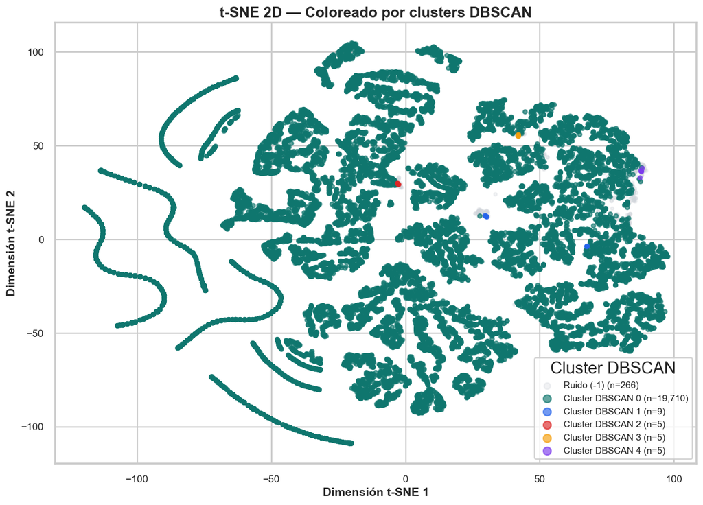

```
Gráfico guardado: tsne_clusters_dbscan.png
```

```python
# ── t-SNE coloreado por cluster DBSCAN ───────────────────────────────────────
df_tsne_no_noise = customer_features[customer_features["cluster_dbscan"] != -1]
df_tsne_noise    = customer_features[customer_features["cluster_dbscan"] == -1]

plt.figure(figsize=(11, 8))

# Grafica el ruido primero (fondo gris) para que los clusters queden encima.
plt.scatter(
    df_tsne_noise["tsne_1"], df_tsne_noise["tsne_2"],
    c="#D1D5DB", alpha=0.3, s=12,
    label=f"Ruido (-1) (n={len(df_tsne_noise):,})"
)

# Grafica cada cluster DBSCAN con color vívido.
for idx, cluster_id in enumerate(sorted(df_tsne_no_noise["cluster_dbscan"].unique())):
    subset = df_tsne_no_noise[df_tsne_no_noise["cluster_dbscan"] == cluster_id]
    plt.scatter(
        subset["tsne_1"], subset["tsne_2"],
        c=PALETTE_VIVID[idx % len(PALETTE_VIVID)],
        alpha=0.65, s=18,
        label=f"Cluster DBSCAN {cluster_id} (n={len(subset):,})"
    )

plt.title("t-SNE 2D — Coloreado por clusters DBSCAN",
          fontsize=16, fontweight="bold")
plt.xlabel("Dimensión t-SNE 1")
plt.ylabel("Dimensión t-SNE 2")
plt.legend(title="Cluster DBSCAN", fontsize=10, markerscale=2)
plt.tight_layout()
f_save_plot("tsne_clusters_dbscan.png", FIGURES_TSNE)
plt.show()
print("Gráfico guardado: tsne_clusters_dbscan.png")
```

## 9. Comparación K-Means vs DBSCAN

Se construye una tabla y gráficos comparativos entre ambos modelos evaluando:

- Número de clusters generados
- Porcentaje de puntos clasificados como ruido (solo DBSCAN)
- Silhouette Score de cada modelo
- Capacidad de detectar formas arbitrarias vs esféricas

```python
# ─────────────────────────────────────────────────────────────────────────────
# CELDA DE INICIALIZACIÓN — Agrega columna "cluster_kmeans" a customer_features
#
# X_scaled ya existe en memoria (confirmado por diagnóstico).
# Solo se entrena K-Means y se añade la columna que faltaba.
# ─────────────────────────────────────────────────────────────────────────────
from sklearn.cluster import KMeans
from sklearn.metrics import silhouette_score

# Entrena K-Means con k=2 (óptimo del notebook 03, Silhouette=0.30)
kmeans_final = KMeans(n_clusters=2, random_state=42, n_init=20)
customer_features["cluster_kmeans"] = kmeans_final.fit_predict(X_scaled)

# Calcula silhouette score de K-Means (se usará en celda 33)
sil_kmeans = silhouette_score(X_scaled, customer_features["cluster_kmeans"])

# Recupera métricas de DBSCAN desde lo que ya existe en memoria
labels_db     = customer_features["cluster_dbscan"]
n_noise       = int((labels_db == -1).sum())
pct_noise     = n_noise / len(labels_db) * 100
n_clusters_dbscan = int(labels_db[labels_db != -1].nunique())
mask_db       = labels_db != -1
sil_dbscan    = silhouette_score(X_scaled[mask_db], labels_db[mask_db])

# Verificación
print(f"cluster_kmeans agregado ✓")
print(f"Silhouette K-Means : {sil_kmeans:.4f}")
print(f"Silhouette DBSCAN  : {sil_dbscan:.4f}")
print(f"Clusters DBSCAN    : {n_clusters_dbscan}  |  Ruido: {n_noise} ({pct_noise:.1f}%)")
print(f"\nDistribución K-Means:")
print(customer_features["cluster_kmeans"].value_counts().sort_index())
```

```
cluster_kmeans agregado ✓
Silhouette K-Means : 0.2994
Silhouette DBSCAN  : 0.4491
Clusters DBSCAN    : 5  |  Ruido: 266 (1.3%)

Distribución K-Means:
cluster_kmeans
0     7041
1    12959
Name: count, dtype: int64
```

```python
# ── Tabla comparativa de métricas entre K-Means y DBSCAN ─────────────────────
comparison_data = {
    "Modelo":                    ["K-Means",                    "DBSCAN"],
    "N° Clusters":               [2,                             n_clusters_dbscan],
    "Puntos de Ruido":           ["0 (0.0%)",                   f"{n_noise} ({pct_noise:.1f}%)"],
    "Silhouette Score":          [f"{sil_kmeans:.4f}",           f"{sil_dbscan:.4f}"],
    "Detecta formas arbitrarias":["No",                          "Sí"],
    "Sensible a outliers":       ["Sí",                         "No (clasifica como ruido)"],
}

comparison_df = pd.DataFrame(comparison_data)
print("=" * 65)
print("TABLA COMPARATIVA: K-Means vs DBSCAN")
print("=" * 65)
print(comparison_df.to_string(index=False))

comparison_df.to_csv(TABLES_DIR / "comparacion_kmeans_dbscan.csv", index=False)
print("\nTabla guardada: comparacion_kmeans_dbscan.csv ✓")
```

```
=================================================================
TABLA COMPARATIVA: K-Means vs DBSCAN
=================================================================
 Modelo  N° Clusters Puntos de Ruido Silhouette Score Detecta formas arbitrarias       Sensible a outliers
K-Means            2        0 (0.0%)           0.2994                         No                        Sí
 DBSCAN            5      266 (1.3%)           0.4491                         Sí No (clasifica como ruido)

Tabla guardada: comparacion_kmeans_dbscan.csv ✓
```

```python
print("FIGURES_CMP:", FIGURES_CMP)
print("PALETTE_VIVID:", PALETTE_VIVID)
```

```
FIGURES_CMP: G:\ProyectosPython\proyecto3\desarrollo3\reports\figures\clustering_clientes
PALETTE_VIVID: ['#0F766E', '#2563EB', '#DC2626', '#F59E0B', '#7C3AED', '#059669', '#EA580C', '#DB2777', '#0891B2', '#65A30D']
```

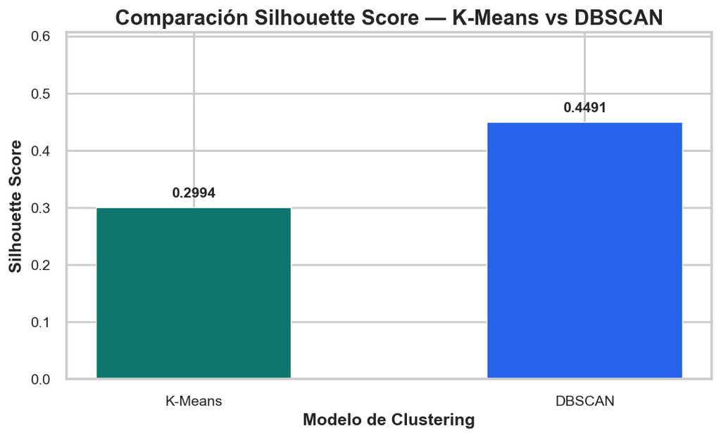

```
Gráfico guardado ✓
```

```python
# ── Comparación Silhouette Score: K-Means vs DBSCAN ──────────────────────────
import matplotlib.pyplot as plt

score_df = pd.DataFrame({
    "Modelo":           ["K-Means", "DBSCAN"],
    "Silhouette Score": [sil_kmeans, sil_dbscan],
})

fig, ax = plt.subplots(figsize=(8, 5))
bars = ax.bar(
    score_df["Modelo"],
    score_df["Silhouette Score"],
    color=[PALETTE_VIVID[0], PALETTE_VIVID[1]],
    edgecolor="white", linewidth=0.8, width=0.5
)

for bar in bars:
    h = bar.get_height()
    ax.annotate(f"{h:.4f}",
                xy=(bar.get_x() + bar.get_width() / 2, h),
                xytext=(0, 6), textcoords="offset points",
                ha="center", va="bottom", fontsize=11, fontweight="bold")

ax.set_title("Comparación Silhouette Score — K-Means vs DBSCAN", fontweight="bold")
ax.set_xlabel("Modelo de Clustering")
ax.set_ylabel("Silhouette Score")
ax.set_ylim(0, max(sil_kmeans, sil_dbscan) * 1.35)
plt.tight_layout()
plt.savefig(
    FIGURES_CMP / "comparacion_silhouette_kmeans_dbscan.png",
    dpi=400, bbox_inches="tight", facecolor="white"
)
plt.show()
print("Gráfico guardado ✓")
```

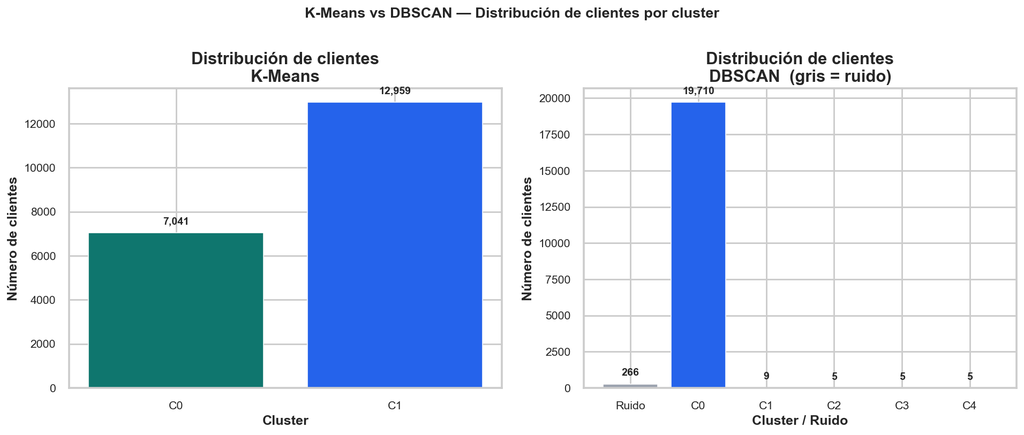

```
Gráfico guardado ✓
```

```python
# ── Distribución de clientes por cluster: K-Means vs DBSCAN ──────────────────
km_counts = (
    customer_features["cluster_kmeans"]
    .value_counts().sort_index().reset_index()
)
km_counts.columns = ["cluster", "count"]
km_counts["label"] = km_counts["cluster"].apply(lambda x: f"C{int(x)}")

db_counts = (
    customer_features["cluster_dbscan"]
    .value_counts().sort_index().reset_index()
)
db_counts.columns = ["cluster", "count"]
db_counts["label"] = db_counts["cluster"].apply(
    lambda x: "Ruido" if int(x) == -1 else f"C{int(x)}"
)

fig, axes = plt.subplots(1, 2, figsize=(14, 6))

# Panel izquierdo: K-Means
ax0 = axes[0]
km_colors = [PALETTE_VIVID[i % len(PALETTE_VIVID)] for i in range(len(km_counts))]
bars0 = ax0.bar(km_counts["label"], km_counts["count"],
                color=km_colors, edgecolor="white", linewidth=0.8)
for bar in bars0:
    h = bar.get_height()
    ax0.annotate(f"{int(h):,}",
                 xy=(bar.get_x() + bar.get_width() / 2, h),
                 xytext=(0, 6), textcoords="offset points",
                 ha="center", va="bottom", fontsize=10, fontweight="bold")
ax0.set_title("Distribución de clientes\nK-Means", fontweight="bold")
ax0.set_xlabel("Cluster")
ax0.set_ylabel("Número de clientes")

# Panel derecho: DBSCAN
ax1 = axes[1]
db_colors = [
    "#9CA3AF" if int(row["cluster"]) == -1
    else PALETTE_VIVID[i % len(PALETTE_VIVID)]
    for i, row in db_counts.iterrows()
]
bars1 = ax1.bar(db_counts["label"], db_counts["count"],
                color=db_colors, edgecolor="white", linewidth=0.8)
for bar in bars1:
    h = bar.get_height()
    ax1.annotate(f"{int(h):,}",
                 xy=(bar.get_x() + bar.get_width() / 2, h),
                 xytext=(0, 6), textcoords="offset points",
                 ha="center", va="bottom", fontsize=10, fontweight="bold")
ax1.set_title("Distribución de clientes\nDBSCAN  (gris = ruido)", fontweight="bold")
ax1.set_xlabel("Cluster / Ruido")
ax1.set_ylabel("Número de clientes")

plt.suptitle("K-Means vs DBSCAN — Distribución de clientes por cluster",
             fontsize=14, fontweight="bold")
plt.tight_layout()
plt.savefig(
    FIGURES_CMP / "comparacion_distribucion_kmeans_dbscan.png",
    dpi=400, bbox_inches="tight", facecolor="white"
)
plt.show()
print("Gráfico guardado ✓")
```